# Cancer Dependency Explorer

This pipeline integrates CRISPR dependency with lineage, expression, copy number and damaging somatic mutations from **DepMap Public 26Q1**. Please note, throughout the report, more negative Chronos scores indicate that knocking out the target gene has a stronger effect on cell fitness. This is interpreted as stronger dependency on the target gene selected, in this case: **SOX10**.

This report addresses the following question:

**Which molecular features are associated with dependency on SOX10, and which exploratory molecular predictors are reproducible in held-out cancer cell line models?**

In other words, the report first describes individual associations and then asks which eligible molecular features remain useful when every modality is considered jointly after adjustment for cancer lineage.

The overall report narrative is structured as follows:

- Eligibility and data quality
- Dependency distribution and cancer-lineage characterisation
- Self-associations between the dependency of SOX10 and its own expression, damaging mutation and copy number
- Associations between the dependency of SOX10 and pre-specified hypotheses, plus accountability for lineage-specific effects
- Associations between the dependency of SOX10 and genome-wide expression, damaging mutation and copy number
- Integrated exploratory modelling
- Nested cross-validation performance

# How to read this report

The purpose of this report is to explain why cancer cell line models differ in their dependency on **SOX10**, going from simple descriptions to an integrated analysis. First, it asks whether each measurement is reliable enough to analyse. It then shows what each feature does by itself, before allowing every eligible molecular feature to compete under the same regularization after adjustment for cancer lineage. The final results are a prioritisation of reproducible exploratory predictors.

The analysis has four layers:

### 1. Eligibility: can the feature be analysed reliably?

Eligibility is a data quality decision made before interpreting an association. Features are excluded when the available data cannot support the planned comparison. This is the first layer of data filtering and applies in all analyses.

| Feature type | Eligibility rule | Biological/statistical reason |
| --- | --- | --- |
| Expression | Observed in at least 80% of models with any expression-assay data and has nonzero variance | A feature needs sufficient coverage and variation within the assayed models to compare them meaningfully. |
| Copy number | Observed in at least 80% of models with any copy-number-assay data and has nonzero variance | Sparse or constant measurements within the assayed models cannot support a reliable correlation. |
| Damaging mutation | At least 10 altered and 10 wild type models | Both biological groups must be represented well enough for an altered-versus-wild type comparison. |

As per the data, there are three types of features described below. These modality rules apply equally to all three roles:

- **Target-characterisation features:** SOX10 expression, damaging mutation and copy number.
- **Pre-specified hypotheses:** features supplied in SOX10_biomarkers.yml are nominated before modelling from existing biological knowledge. YAML designation does not override insufficient coverage, zero variance or the mutation 10/10 rule.
- **Genome-wide candidates:** every other expression, mutation and copy number feature that passes the same basic modality-specific eligibility rule enters the integrated molecular search.

### 2. Univariate association: what does each feature show by itself?

The univariate screen asks: **is this feature associated with SOX10 dependency when considered on its own?** For example, it tests whether SOX10 Chronos scores increases or decreases with Gene X expression, or whether models carrying a damaging Gene X mutation have different SOX10 dependency scores from Gene X wild type models.

- Expression uses a Spearman correlation, making it less sensitive to extreme values and distributional assumptions. Negative correlation indicates stronger dependency as expression increases.
- Damaging mutations use R’s built-in unequal-variance Welch t-test to compare mean dependency in altered and wild type models. The mean difference, 95% confidence interval and P value come from the same test.
- Copy number uses Pearson correlation, which is appropriate for continuous measurements that are approximately normally distributed.

FDR is calculated per modality. An expression result is considered notable when FDR < 0.05 and |Spearman rho| >= 0.30; a copy number result requires FDR < 0.05 and |Pearson r| >= 0.30; a mutation result requires FDR < 0.05. These thresholds identify significant associations only.

### 3. Predictor designation: how is each eligible feature treated?

After eligibility is established, the integrated model treats every eligible molecular feature equally, without privileging a particular modality or pre-specified hypothesis. The model uses elastic-net regularization to select a subset of features that reproducibly predict SOX10 dependency in held-out cell line models.

- **Target characterisation:** eligible SOX10 expression, damaging mutation and copy number describe the molecular state of the target.
- **Pre-specified hypothesis:** eligible YAML features represent hypotheses nominated before modelling from biological knowledge.
- **Genome-wide candidate:** every other eligible expression, mutation and copy-number feature.
- **Lineage adjustment:** cancer-lineage indicators account for broad histological differences that could otherwise make a molecular feature appear associated simply because it is enriched in a more- or less-dependent lineage.

Every eligible molecular feature enters with penalty factor 1 and can be reduced to zero. Only lineage indicators receive penalty factor 0.

### 4. Integrated exploratory model: what remains useful when the data are considered together?

The integrated model asks: **after adjusting for cancer lineage, which eligible molecular features contribute reproducibly to prediction of SOX10 dependency when all molecular measurements compete under the same regularization?**

The parameter choices are:

- **Gaussian model:** Chronos dependency is a continuous numerical measurement, so the model predicts a number rather than a category.
- **Elastic net balance (`alpha = 0.5`):** this is a middle ground balance between selecting a small set of features and retaining groups of correlated biological features that may be correlated and carry similar information.
- **One SD lambda:** several model sizes may predict almost equally well. This rule chooses the simpler, more strongly regularized model when its estimated error is still statistically comparable to the best performing model.
- **Nested cross-validation:** the same training portion is used for feature selection and parameter choice, and the outer held-out portion is used to estimate performance. This avoids overfitting and data leakage.
- **Repeated folds:** repeating the five-fold analysis three times reduces dependence on one arbitrary division of the dataset.

**Read more details on the model construction**

In concrete terms, each repeat divides the cell line models into five lineage-balanced outer folds, which can be called A–E. The model is trained on A–D and tested on E, then trained on A–C plus E and tested on D, continuing until each fold has served as the test set once. Within every four-fold training portion, a separate five-fold inner cross-validation chooses the one-standard-error lambda; the outer test fold is not used for preprocessing, feature selection or parameter choice. The full A–E assignment is then reshuffled, while preserving lineage balance, and the process is repeated twice more. Thus, the procedure produces 15 outer fitted models and three complete sets of held-out predictions, one set per repeat.

The results are collated in three ways:

- **Held-out performance:** within each repeat, the five outer test-fold predictions are joined so every cell model has one held-out prediction. Pearson r, RMSE and R² are calculated for that complete prediction set. The report then summarizes their variation across the three repeats.
- **Molecular feature stability:** for each molecular feature, selection is counted across all 15 outer models. Selection frequency is the number of nonzero coefficients divided by 15. Direction concordance is the proportion of the feature’s nonzero coefficients that agree with its most common direction.
- **Full-data fit and reported stable set:** the same model specification is fitted once more using all eligible cell line models, with inner cross-validation choosing `lambda.1se`. A molecular feature is reported as stable only when its outer-model selection frequency is at least 60%, its direction concordance is at least 80%, and its coefficient is also nonzero in this full-data fit. The displayed coefficient comes from that fit, and the stable set is a reporting filter, not a second refitted model.

A molecular feature is called stable only if it is selected in at least 60% of outer models, has the same coefficient direction in at least 80% of models in which it is selected, and remains nonzero in the full-data fit.

The report therefore presents selection frequency, direction concordance and nested-CV Pearson r, RMSE and R². Stable genes are exploratory molecular predictors associated with SOX10 dependency ready to follow-up in future experiments.

# Data quality

This section establishes if the data are sufficient to run the planned analyses using data extracted from the DepMap Public release.

Pre-analysis data-quality checks

| check | passed | detail |
| --- | --- | --- |
| Target in CRISPR matrix | TRUE | SOX10 |
| Unique ModelID after multiomic joins | TRUE | 1208 |
| At least 50 dependency observations | TRUE | 1208 |
| At least 50 models with lineage annotation | TRUE | 1208 |
| Expression has nonzero variance | TRUE | SD 1.878 |
| Copy number has nonzero variance | TRUE | SD 0.232 |

6 of 6 checks passed (a failed check is retained in this report but critical failures stop the workflow ahead of modelling).

Expression-assay measurements were available for **1140 of 1208 models (94.4%)**, and copy-number measurements for **858 of 1208 models (71.0%)**. The 80% feature-level eligibility threshold is evaluated among models with any data from the corresponding assay, rather than across all dependency models. Models without that assay remain in the integrated analysis; their missing molecular values are replaced using medians learned from the relevant training fold.

# Dependency distribution

The first exploratory question is whether dependency on SOX10 is observed in a subset of DepMap pancancer cell line models or is a broadly distributed dependency. The distribution of Chronos scores across all models is shown below:

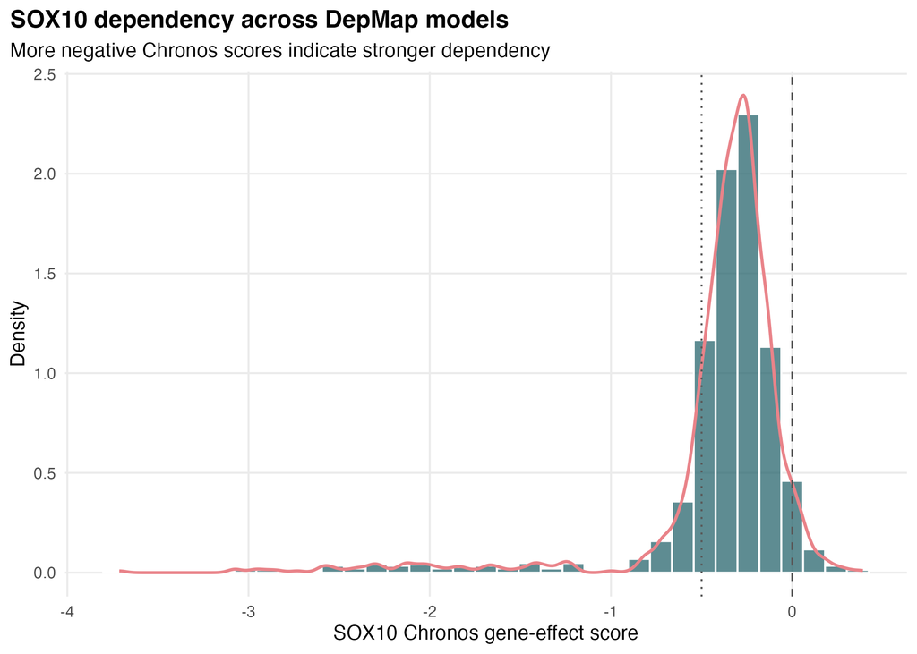

Across 1208 models, the median SOX10 Chronos score was -0.306. The proportion of cell lines with Chronos scores below -0.5 (what is generally considered as *strong dependency*) was 16.7%.

# Lineage specificity

Cancer types can differ in which genes they require for survival. Before examining individual molecular features, the question is whether SOX10 dependency is concentrated in particular cancer lineages. The plot below shows the size and direction of these differences, while the global Kruskal–Wallis test evaluates if there is evidence of an overall lineage association.

The global comparison found evidence that **SOX10 dependency differs across cancer lineages** (Kruskal–Wallis P = 1.6e-32). This means that at least one lineage has a different dependency distribution; the comparisons below show which lineages may contribute to the pattern.

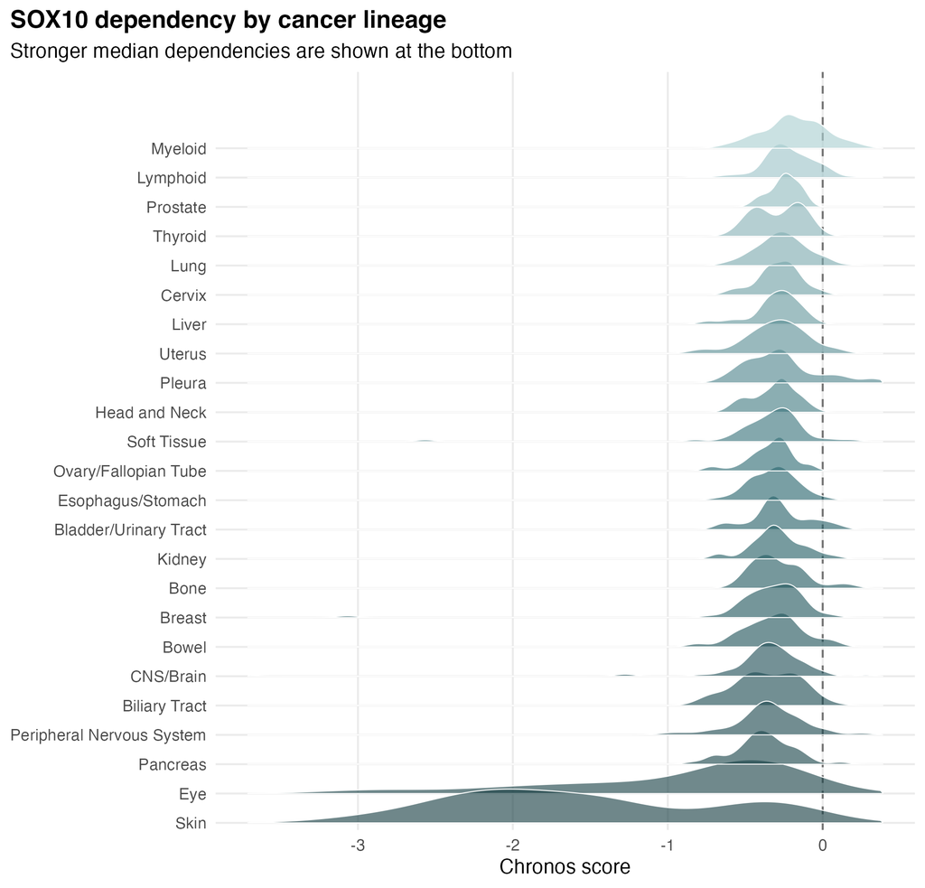

To identify which lineages may contribute to this variation, each lineage was compared with all other eligible lineages combined. The table reports the leading lineage-versus-rest results. Negative **median differences** indicate stronger dependency in that lineage, whereas positive differences indicate weaker dependency.

Leading lineage associations

|  | lineage | n | mean | median | rest_n | rest_median | median_difference | p_value | fdr |
| --- | --- | --- | --- | --- | --- | --- | --- | --- | --- |
| 1 | Skin | 75 | -1.549 | -1.670 | 1118 | -0.294 | -1.376 | 0.000 | 0.000 |
| 23 | Lymphoid | 96 | -0.218 | -0.231 | 1097 | -0.317 | 0.086 | 0.000 | 0.000 |
| 24 | Myeloid | 45 | -0.186 | -0.211 | 1148 | -0.312 | 0.101 | 0.000 | 0.000 |
| 2 | Eye | 15 | -0.931 | -0.501 | 1178 | -0.303 | -0.198 | 0.000 | 0.000 |
| 20 | Lung | 126 | -0.263 | -0.258 | 1067 | -0.313 | 0.056 | 0.000 | 0.002 |
| 3 | Pancreas | 48 | -0.384 | -0.385 | 1145 | -0.302 | -0.083 | 0.015 | 0.059 |
| 22 | Prostate | 10 | -0.247 | -0.239 | 1183 | -0.306 | 0.067 | 0.136 | 0.465 |
| 4 | Peripheral Nervous System | 47 | -0.350 | -0.364 | 1146 | -0.304 | -0.060 | 0.306 | 0.702 |
| 5 | Biliary Tract | 34 | -0.358 | -0.359 | 1159 | -0.305 | -0.054 | 0.381 | 0.702 |
| 6 | CNS/Brain | 91 | -0.379 | -0.340 | 1102 | -0.303 | -0.037 | 0.352 | 0.702 |

**Skin** (median difference -1.38; FDR 2e-28) and **Eye** (median difference -0.198; FDR 2e-04) contributed to the lineage association through more-negative dependency scores than the remaining models, indicating **stronger SOX10 dependency** in those cancer contexts. **Lymphoid** (median difference +0.086; FDR 3.3e-07) and **Myeloid** (median difference +0.101; FDR 4.5e-05) contributed through more-positive scores, indicating **weaker SOX10 dependency** relative to the remaining models. These results show that lineage captures systematic differences in dependency and could confound molecular associations.

Interpretation note: Lineage associations may reflect molecular features enriched in particular histologies. For example, an apparent association between Gene X mutation and SOX10 dependency could partly arise because the mutation is common in a lineage already more dependent on SOX10. The integrated model therefore forces lineage indicators into every fit to reduce this potential confounding.

# Target characterisation

Next, the selected target SOX10’s expression, damaging mutation status and copy number were evaluated for association with SOX10 dependency. The table below shows the corresponding statistical results.

The plot below shows the correlation between dependency and the target’s own expression.

SOX10 molecular-state associations with dependency

| Feature | Test | N | Estimate type | Estimate | P value | FDR | Eligible |
| --- | --- | --- | --- | --- | --- | --- | --- |
| SOX10 expression | Spearman correlation | 1140 | Spearman rho | -0.149 | 0 | 0 | TRUE |
| SOX10 damaging mutation | Welch mean comparison | 3 altered / 1205 reference | Altered minus reference | 0.111 | NA | NA | FALSE |
| SOX10 copy number | Pearson correlation | 858 | Pearson r | -0.316 | 0 | 0 | TRUE |

For the expression and copy number rows, a negative correlation indicates stronger dependency as the measurement increases. For the mutation row, a negative estimate indicates stronger dependency in models carrying a damaging mutation. These are unadjusted associations and may reflect lineage or other correlated molecular features.

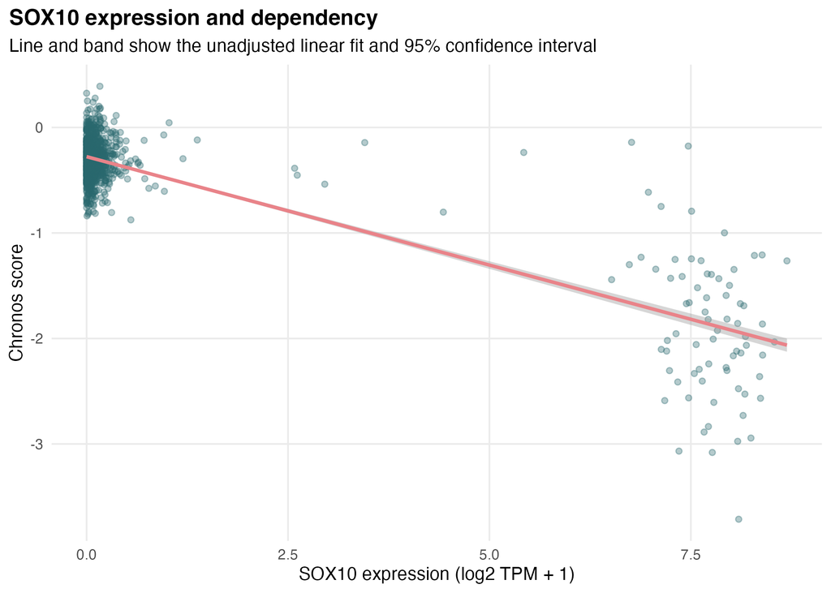

**Interpretations**

**Expression**

A negative expression–dependency correlation can indicate that cells hyperexpressing SOX10 are more reliant on it (sometimes called an expression-linked dependency or “addiction”). This may suggest that the active pathway or cellular state marked by high expression requires that gene.

A positive correlation means highly expressing cells are less sensitive to knockout. This could reflect compensatory expression, association with a resistant lineage, or stronger dependency among low-expression cells.

**Damaging mutations**

If $\Delta$ (altered - wild type) < 0, cells carrying a damaging mutation are more dependent on that gene. This may indicate that the mutation is activating, dominant negative, or otherwise sensitising.

If $\Delta$ (altered - wild type) > 0, mutated cells are less dependent on the target. This may indicate pathway redundancy, target-pathway inactivation, or resistance.

For a gene’s mutation versus its own dependency, a positive difference is often biologically plausible: if the gene is already functionally inactivated, CRISPR knockout may have little additional effect.

**Copy number**

A negative correlation means higher copy number is associated with stronger target dependency. For the target’s own copy number, this can suggest an amplification-associated dependency: amplified cells may become reliant on the overactive or overexpressed target.

A positive correlation means higher copy number is associated with weaker dependency, or equivalently, lower copy number cells are more dependent. This might reflect vulnerability after partial deletion, dosage-sensitive biology, lineage differences, or genomic features linked to the copy number event.

# Pre-specified hypotheses

Features listed in **SOX10_biomarkers.yml** are pre-specified hypotheses nominated before modelling from existing biological knowledge. Their designation makes their results easy to follow but does not force them into the fitted result or change their penalty. Each eligible hypothesis competes on equal terms with every other molecular feature (see 3. Predictor designation: how is each eligible feature treated?). Their pan-cancer results are shown below under each nominated gene.

## MITF

MITF molecular-state associations with SOX10 dependency

|  | Feature | Modality | Test | N | Estimate type | Estimate | P value | FDR | Eligible |
| --- | --- | --- | --- | --- | --- | --- | --- | --- | --- |
| 1 | MITF expression | Expression | Spearman correlation | 1140 | Spearman rho | -0.217 | 0 | 0 | TRUE |
| 10 | MITF copy number | Copy number | Pearson correlation | 858 | Pearson r | -0.427 | 0 | 0 | TRUE |

## PAX3

PAX3 molecular-state associations with SOX10 dependency

|  | Feature | Modality | Test | N | Estimate type | Estimate | P value | FDR | Eligible |
| --- | --- | --- | --- | --- | --- | --- | --- | --- | --- |
| 2 | PAX3 expression | Expression | Spearman correlation | 1140 | Spearman rho | -0.135 | 0 | 0 | TRUE |

## TFAP2A

TFAP2A molecular-state associations with SOX10 dependency

|  | Feature | Modality | Test | N | Estimate type | Estimate | P value | FDR | Eligible |
| --- | --- | --- | --- | --- | --- | --- | --- | --- | --- |
| 3 | TFAP2A expression | Expression | Spearman correlation | 1140 | Spearman rho | -0.164 | 0 | 0 | TRUE |

## TYRO3

TYRO3 molecular-state associations with SOX10 dependency

|  | Feature | Modality | Test | N | Estimate type | Estimate | P value | FDR | Eligible |
| --- | --- | --- | --- | --- | --- | --- | --- | --- | --- |
| 4 | TYRO3 expression | Expression | Spearman correlation | 1140 | Spearman rho | -0.172 | 0 | 0 | TRUE |

## ERBB3

ERBB3 molecular-state associations with SOX10 dependency

|  | Feature | Modality | Test | N | Estimate type | Estimate | P value | FDR | Eligible |
| --- | --- | --- | --- | --- | --- | --- | --- | --- | --- |
| 5 | ERBB3 expression | Expression | Spearman correlation | 1140 | Spearman rho | -0.198 | 0 | 0 | TRUE |

## AXL

AXL molecular-state associations with SOX10 dependency

|  | Feature | Modality | Test | N | Estimate type | Estimate | P value | FDR | Eligible |
| --- | --- | --- | --- | --- | --- | --- | --- | --- | --- |
| 6 | AXL expression | Expression | Spearman correlation | 1140 | Spearman rho | -0.095 | 0.001 | 0.006 | TRUE |

## NF1

NF1 molecular-state associations with SOX10 dependency

|  | Feature | Modality | Test | N | Estimate type | Estimate | P value | FDR | Eligible |
| --- | --- | --- | --- | --- | --- | --- | --- | --- | --- |
| 7 | NF1 damaging mutation | Mutation | Welch mean comparison | 83 altered / 1125 wild type | Altered minus wild type | 0.013 | 0.763 | 0.886 | TRUE |

## CDKN2A

CDKN2A molecular-state associations with SOX10 dependency

|  | Feature | Modality | Test | N | Estimate type | Estimate | P value | FDR | Eligible |
| --- | --- | --- | --- | --- | --- | --- | --- | --- | --- |
| 8 | CDKN2A damaging mutation | Mutation | Welch mean comparison | 140 altered / 1068 wild type | Altered minus wild type | -0.108 | 0.016 | 0.068 | TRUE |

## PTEN

PTEN molecular-state associations with SOX10 dependency

|  | Feature | Modality | Test | N | Estimate type | Estimate | P value | FDR | Eligible |
| --- | --- | --- | --- | --- | --- | --- | --- | --- | --- |
| 9 | PTEN damaging mutation | Mutation | Welch mean comparison | 124 altered / 1084 wild type | Altered minus wild type | 0.026 | 0.5 | 0.716 | TRUE |

## EP300

EP300 molecular-state associations with SOX10 dependency

|  | Feature | Modality | Test | N | Estimate type | Estimate | P value | FDR | Eligible |
| --- | --- | --- | --- | --- | --- | --- | --- | --- | --- |
| 11 | EP300 copy number | Copy number | Pearson correlation | 858 | Pearson r | -0.257 | 0 | 0 | TRUE |

# Lineage-specific molecular associations

An additional layer of the analysis computes associations between SOX10 dependency and its target-characterisation features, and between SOX10 dependency and the pre-specified hypotheses, but this time within each cancer lineage. This evaluates whether a pancancer association may be driven by lineage composition and identifies the lineages in which it is supported.

The combined table below retains both estimable and non-estimable target/pre-specified-hypothesis rows (sorted by FDR). When a lineage lacks enough models, variation or mutation group stratification, the *Reason* column explains why no estimate or FDR is available.

**Target and pre-specified-hypothesis associations within lineages, ordered by FDR**

| Source | Feature | Modality | Lineage | N | Altered N | Wild type N | Estimate type | Estimate | FDR | 95% CI low | 95% CI high | P value | Estimable | Reason | FDR sort |
| --- | --- | --- | --- | --- | --- | --- | --- | --- | --- | --- | --- | --- | --- | --- | --- |
| Target characterisation | SOX10 expression | Expression | Skin | 74 |  |  | Chronos change per 1 overall SD increase | -0.393185253313885 | 0.000 | -0.434372696802029 | -0.351997809825741 | 8.301055891383189e-30 | True | Estimated | 1.69341540184217e-27 |
| Pre-specified hypothesis | ERBB3 expression | Expression | Skin | 74 |  |  | Chronos change per 1 overall SD increase | -0.644354201188287 | 0.000 | -0.745474845223617 | -0.543233557152957 | 4.61911782510473e-20 | True | Estimated | 4.71150018160682e-18 |
| Pre-specified hypothesis | MITF expression | Expression | Skin | 74 |  |  | Chronos change per 1 overall SD increase | -0.384703354720811 | 0.000 | -0.506837355166955 | -0.262569354274668 | 2.28831646948516e-08 | True | Estimated | 1.55605519924991e-06 |
| Pre-specified hypothesis | PAX3 expression | Expression | Skin | 74 |  |  | Chronos change per 1 overall SD increase | -0.351650516166913 | 0.000 | -0.467412316455389 | -0.235888715878437 | 5.76573819383768e-08 | True | Estimated | 2.94052647885722e-06 |
| Pre-specified hypothesis | TYRO3 expression | Expression | Skin | 74 |  |  | Chronos change per 1 overall SD increase | -0.559839110246645 | 0.000 | -0.75355137577448 | -0.366126844718809 | 1.91847058429608e-07 | True | Estimated | 7.827359983928e-06 |
| Pre-specified hypothesis | AXL expression | Expression | Skin | 74 |  |  | Chronos change per 1 overall SD increase | 0.323124352614423 | 0.009 | 0.154698946267727 | 0.491549758961119 | 0.000276248119747044 | True | Estimated | 0.00939243607139949 |
| Pre-specified hypothesis | CDKN2A damaging mutation | Damaging mutation | Esophagus/Stomach | 69 | 10 | 59 | Altered minus reference | -0.116682260555493 | 0.014 | -0.180166905426258 | -0.0531976156847292 | 0.000484472848162937 | True | Estimated | 0.0141189230036056 |
| Pre-specified hypothesis | MITF copy number | Copy number | Uterus | 25 |  |  | Chronos change per 1 overall SD increase | 0.305130413675172 | 0.055 | 0.122425365002897 | 0.487835462347447 | 0.00215229293420359 | True | Estimated | 0.0548834698221915 |
| Target characterisation | SOX10 copy number | Copy number | Bone | 50 |  |  | Chronos change per 1 overall SD increase | -0.0443039970542055 | 0.237 | -0.0787367893494647 | -0.00987120475894632 | 0.0127658206893336 | True | Estimated | 0.237153514606989 |
| Pre-specified hypothesis | AXL expression | Expression | Bone | 49 |  |  | Chronos change per 1 overall SD increase | -0.0549455230552335 | 0.237 | -0.0977108228339378 | -0.0121802232765292 | 0.0129109885583074 | True | Estimated | 0.237153514606989 |

[output cut: 370 more lines]

**The following association(s) passed the 5% lineage-specific FDR threshold:**

- **SOX10 expression was associated with stronger SOX10 dependency in Skin** (estimate -0.393 change in Chronos score per 1 overall SD increase; 95% CI -0.434 to -0.352; FDR 1.7e-27).
- **ERBB3 expression was associated with stronger SOX10 dependency in Skin** (estimate -0.644 change in Chronos score per 1 overall SD increase; 95% CI -0.745 to -0.543; FDR 4.7e-18).
- **MITF expression was associated with stronger SOX10 dependency in Skin** (estimate -0.385 change in Chronos score per 1 overall SD increase; 95% CI -0.507 to -0.263; FDR 1.6e-06).
- **PAX3 expression was associated with stronger SOX10 dependency in Skin** (estimate -0.352 change in Chronos score per 1 overall SD increase; 95% CI -0.467 to -0.236; FDR 2.9e-06).
- **TYRO3 expression was associated with stronger SOX10 dependency in Skin** (estimate -0.56 change in Chronos score per 1 overall SD increase; 95% CI -0.754 to -0.366; FDR 7.8e-06).
- **AXL expression was associated with weaker SOX10 dependency in Skin** (estimate 0.323 change in Chronos score per 1 overall SD increase; 95% CI 0.155 to 0.492; FDR 0.009).
- **CDKN2A damaging mutation was associated with stronger SOX10 dependency in Esophagus/Stomach** (estimate -0.117 change in Chronos score in altered versus wild type models; 95% CI -0.18 to -0.0532; FDR 0.014).

# Genomic associations

The following sections show the leading genes from the complete genome-wide univariate screens. The aim is to identify genome-wide molecular features flagging models with stronger or weaker SOX10 dependency.

Look out for coloured points for each modality in the plots below indicating features that passed the thresholds for significance (FDR < 0.05 and |rho| >= 0.30 for expression, FDR < 0.05 for mutation, and FDR < 0.05 and |r| >= 0.30 for copy number).

### Gene expression

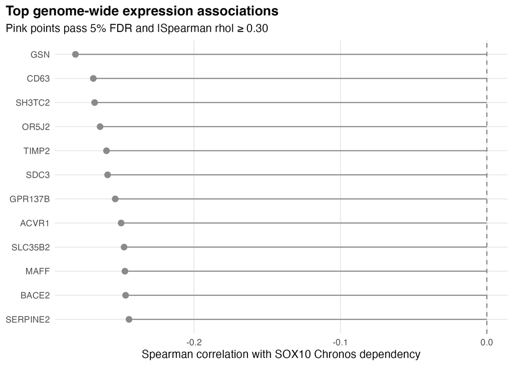

No genome-wide expression correlation was both significant at 5% FDR and at least moderate in magnitude (|rho| >= 0.30). This screen found no substantial expression association with `SOX10` dependency.

**View detailed expression results**

Top genome-wide expression associations

| gene | n | sd | spearman_rho | p_value | coverage | correlation_strength | eligible | fdr |
| --- | --- | --- | --- | --- | --- | --- | --- | --- |
| GSN | 1140 | 1.949 | -0.281 | 0 | 1 | small | TRUE | 0 |
| CD63 | 1140 | 1.129 | -0.269 | 0 | 1 | small | TRUE | 0 |
| SH3TC2 | 1140 | 1.301 | -0.268 | 0 | 1 | small | TRUE | 0 |
| OR5J2 | 1140 | 0.174 | -0.264 | 0 | 1 | small | TRUE | 0 |
| TIMP2 | 1140 | 2.257 | -0.260 | 0 | 1 | small | TRUE | 0 |
| SDC3 | 1140 | 1.750 | -0.259 | 0 | 1 | small | TRUE | 0 |
| GPR137B | 1140 | 1.481 | -0.254 | 0 | 1 | small | TRUE | 0 |
| ACVR1 | 1140 | 1.130 | -0.250 | 0 | 1 | small | TRUE | 0 |
| SLC35B2 | 1140 | 0.761 | -0.248 | 0 | 1 | small | TRUE | 0 |
| MAFF | 1140 | 1.379 | -0.247 | 0 | 1 | small | TRUE | 0 |

### Damaging mutations

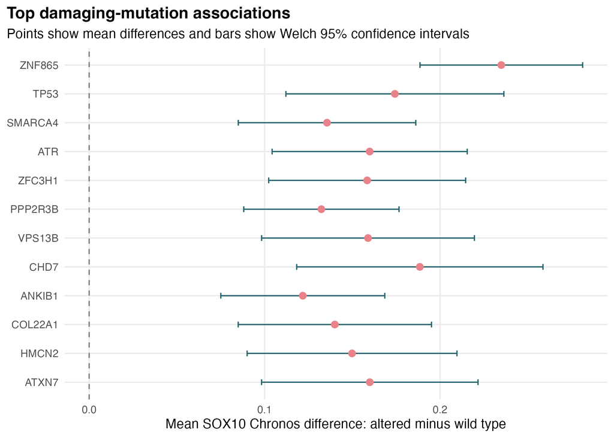

The leading mutation association was **ZNF865** (mean Chronos difference, altered vs wild type: 0.235, FDR 1.8e-06) (a negative difference denotes stronger `SOX10` dependency in defective/altered models).

The plot above summarises the leading mutation associations. Points show altered-minus-wild-type mean differences and error bars show their Welch 95% confidence intervals. Expand the section below to inspect altered and wild type group sizes, mean dependency scores and statistical results.

**View detailed mutation results**

Top damaging mutation associations

| gene | altered_n | reference_n | altered_mean_dependency | reference_mean_dependency | effect | std_error | conf_low | conf_high | p_value | eligible | fdr |
| --- | --- | --- | --- | --- | --- | --- | --- | --- | --- | --- | --- |
| ZNF865 | 10 | 1198 | -0.161 | -0.396 | 0.235 | 0.022 | 0.189 | 0.281 | 0 | TRUE | 0.000 |
| TP53 | 780 | 428 | -0.332 | -0.507 | 0.174 | 0.032 | 0.112 | 0.236 | 0 | TRUE | 0.000 |
| SMARCA4 | 59 | 1149 | -0.265 | -0.401 | 0.136 | 0.026 | 0.085 | 0.186 | 0 | TRUE | 0.000 |
| ATR | 25 | 1183 | -0.238 | -0.397 | 0.160 | 0.028 | 0.104 | 0.215 | 0 | TRUE | 0.000 |
| ZFC3H1 | 20 | 1188 | -0.238 | -0.397 | 0.158 | 0.028 | 0.102 | 0.215 | 0 | TRUE | 0.001 |
| PPP2R3B | 10 | 1198 | -0.263 | -0.395 | 0.132 | 0.021 | 0.088 | 0.177 | 0 | TRUE | 0.001 |
| VPS13B | 29 | 1179 | -0.239 | -0.398 | 0.159 | 0.030 | 0.098 | 0.220 | 0 | TRUE | 0.001 |
| CHD7 | 22 | 1186 | -0.209 | -0.398 | 0.188 | 0.034 | 0.118 | 0.259 | 0 | TRUE | 0.001 |
| ANKIB1 | 15 | 1193 | -0.274 | -0.396 | 0.122 | 0.023 | 0.075 | 0.168 | 0 | TRUE | 0.002 |
| COL22A1 | 22 | 1186 | -0.257 | -0.397 | 0.140 | 0.027 | 0.085 | 0.195 | 0 | TRUE | 0.002 |

### Copy number

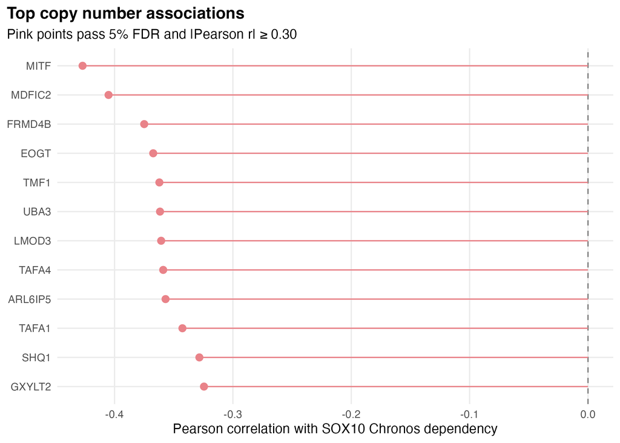

The leading copy number association was **MITF** (a moderate correlation; r -0.427; FDR 4.6e-35). **MITF** showed the strongest association with greater dependency (r = -0.427).

The plot above summarises the leading copy number associations. Pink points pass both the 5% FDR threshold and |Pearson r| >= 0.30; grey points fail one or both criteria. Expand the section below to inspect coverage, correlation magnitude and statistical results.

**View detailed copy number results**

Top copy number associations

| gene | n | coverage | sd | correlation | p_value | eligible | correlation_strength | fdr |
| --- | --- | --- | --- | --- | --- | --- | --- | --- |
| MITF | 858 | 1 | 0.470 | -0.427 | 0 | TRUE | moderate | 0 |
| MDFIC2 | 858 | 1 | 0.341 | -0.405 | 0 | TRUE | moderate | 0 |
| FRMD4B | 858 | 1 | 0.319 | -0.375 | 0 | TRUE | moderate | 0 |
| EOGT | 858 | 1 | 0.357 | -0.367 | 0 | TRUE | moderate | 0 |
| TMF1 | 858 | 1 | 0.367 | -0.362 | 0 | TRUE | moderate | 0 |
| UBA3 | 858 | 1 | 0.343 | -0.362 | 0 | TRUE | moderate | 0 |
| LMOD3 | 858 | 1 | 0.347 | -0.361 | 0 | TRUE | moderate | 0 |
| TAFA4 | 858 | 1 | 0.306 | -0.359 | 0 | TRUE | moderate | 0 |
| ARL6IP5 | 858 | 1 | 0.354 | -0.357 | 0 | TRUE | moderate | 0 |
| TAFA1 | 858 | 1 | 0.272 | -0.343 | 0 | TRUE | moderate | 0 |

# Feature designation for integrated exploratory multiomic modelling

The table below audits the predictors given to the model. Every feature passing the eligibility checks enters the integrated model. Lineage indicators are adjustment covariates and remain in the model always.

Predictors supplied to the integrated exploratory model

| Modality | Feature | Source | Model entry | Predictors entered | Penalty factor | Reason |
| --- | --- | --- | --- | --- | --- | --- |
| Expression | SOX10 | Target characterisation | Entered | 1 | 1 | Entered with the common molecular penalty |
| Damaging mutation | SOX10 | Target characterisation | Omitted | 0 | NA | Omitted: fewer than 10 altered or 10 wild-type models |
| Copy number | SOX10 | Target characterisation | Entered | 1 | 1 | Entered with the common molecular penalty |
| Expression | MITF | Pre-specified hypothesis | Entered | 1 | 1 | Entered with the common molecular penalty |
| Expression | PAX3 | Pre-specified hypothesis | Entered | 1 | 1 | Entered with the common molecular penalty |
| Expression | TFAP2A | Pre-specified hypothesis | Entered | 1 | 1 | Entered with the common molecular penalty |
| Expression | TYRO3 | Pre-specified hypothesis | Entered | 1 | 1 | Entered with the common molecular penalty |
| Expression | ERBB3 | Pre-specified hypothesis | Entered | 1 | 1 | Entered with the common molecular penalty |
| Expression | AXL | Pre-specified hypothesis | Entered | 1 | 1 | Entered with the common molecular penalty |
| Damaging mutation | NF1 | Pre-specified hypothesis | Entered | 1 | 1 | Entered with the common molecular penalty |
| Damaging mutation | CDKN2A | Pre-specified hypothesis | Entered | 1 | 1 | Entered with the common molecular penalty |
| Damaging mutation | PTEN | Pre-specified hypothesis | Entered | 1 | 1 | Entered with the common molecular penalty |
| Copy number | MITF | Pre-specified hypothesis | Entered | 1 | 1 | Entered with the common molecular penalty |
| Copy number | EP300 | Pre-specified hypothesis | Entered | 1 | 1 | Entered with the common molecular penalty |
| Expression | Remaining eligible genome-wide features | Genome-wide candidate | Entered | 19202 | 1 | Entered with the same penalty as target and pre-specified-hypothesis features |
| Damaging mutation | Remaining eligible genome-wide features | Genome-wide candidate | Entered | 1717 | 1 | Entered with the same penalty as target and pre-specified-hypothesis features |
| Copy number | Remaining eligible genome-wide features | Genome-wide candidate | Entered | 19141 | 1 | Entered with the same penalty as target and pre-specified-hypothesis features |
| Annotation | Cancer lineage | Lineage adjustment | Entered | 20 | 0 | Entered without penalization to adjust for histological context |

# Integrated exploratory model

This model asks which molecular features help predict SOX10 dependency when the data are considered together. All eligible expression, mutation and copy number features compete under the same penalty, including the target’s own features and the pre-specified hypotheses. Cancer lineage is included without a penalty to adjust for broad differences between cancer types.

The model uses Gaussian elastic net (`alpha = 0.5`) and the more conservative one-standard-error lambda. Data preparation and feature selection are repeated within the training folds so held-out models do not influence the result. A feature is called *stable* when it is selected repeatedly, keeps the same direction, and is also nonzero in the full-data fit. More construction detail and the exact thresholds are provided in the workflow explanation above (see 4. Integrated exploratory model: what remains useful when the data are considered together?).

**Expand to read about feature preprocessing**

Before entering the Gaussian elastic-net regression, predictors were processed by modality:

- **Expression and copy number:** missing values were replaced with the training-set median. Each feature was then centred and standardized:

  $$z = \frac{x - \text{training mean}}{\text{training SD}}$$
- **Damaging mutations:** missing values were replaced with the most common training-set category, encoded as 0/1, and then centred and standardized using the training-set mutation prevalence and SD.
- **Cancer lineage:** represented by 0/1 indicator variables relative to the most common lineage. These indicators were not standardized and were the only unpenalized predictors.
- **Chronos dependency:** used as the continuous outcome on its original scale rather than standardized, so predictions, residuals and RMSE remain directly interpretable in Chronos units.

For nested cross-validation, imputation values, means and SDs were calculated using only the corresponding outer training set and then applied unchanged to its held-out cell lines. The final full-data model calculated a new set of preprocessing values from the complete dataset.

All molecular features—including target characterisation, pre-specified hypotheses and remaining genome-wide features—received the same modality-appropriate preprocessing and the same penalty factor. `glmnet` was run with `standardize = FALSE` because standardization had already been performed explicitly.

The integrated procedure identified **10 stable molecular predictors**. These are exploratory predictors associated with `SOX10` dependency.

Integrated molecular-search results by source and modality

| Source | Modality | Eligible predictors entered | Selected in at least one outer model | Stable predictors |
| --- | --- | --- | --- | --- |
| Target characterisation | Expression | 1 | 1 | 1 |
| Target characterisation | Copy number | 1 | 0 | 0 |
| Pre-specified hypothesis | Expression | 6 | 0 | 0 |
| Pre-specified hypothesis | Damaging mutation | 3 | 0 | 0 |
| Pre-specified hypothesis | Copy number | 2 | 0 | 0 |
| Genome-wide candidate | Expression | 19202 | 27 | 9 |
| Genome-wide candidate | Damaging mutation | 1717 | 0 | 0 |
| Genome-wide candidate | Copy number | 19141 | 0 | 0 |

### Target and pre-specified hypothesis fate

Target modalities and YAML-listed hypotheses received the same regularization and stability requirements as all other molecular features. The snippet below shows their fate in the integrated model to compared directly with the integrated result.

Target and pre-specified-hypothesis outcomes in the integrated model

| Source | Feature | Modality | Model entry | Selection frequency | Direction concordance | Full-fit coefficient | Status |
| --- | --- | --- | --- | --- | --- | --- | --- |
| Target characterisation | SOX10 | Expression | Entered | 1 | 1 | -0.111 | Stable |
| Target characterisation | SOX10 | Damaging mutation | Omitted | NA | NA | NA | Ineligible |
| Target characterisation | SOX10 | Copy number | Entered | 0 | NA | 0.000 | Not stable |
| Pre-specified hypothesis | MITF | Expression | Entered | 0 | NA | 0.000 | Not stable |
| Pre-specified hypothesis | PAX3 | Expression | Entered | 0 | NA | 0.000 | Not stable |
| Pre-specified hypothesis | TFAP2A | Expression | Entered | 0 | NA | 0.000 | Not stable |
| Pre-specified hypothesis | TYRO3 | Expression | Entered | 0 | NA | 0.000 | Not stable |
| Pre-specified hypothesis | ERBB3 | Expression | Entered | 0 | NA | 0.000 | Not stable |
| Pre-specified hypothesis | AXL | Expression | Entered | 0 | NA | 0.000 | Not stable |
| Pre-specified hypothesis | NF1 | Damaging mutation | Entered | 0 | NA | 0.000 | Not stable |
| Pre-specified hypothesis | CDKN2A | Damaging mutation | Entered | 0 | NA | 0.000 | Not stable |
| Pre-specified hypothesis | PTEN | Damaging mutation | Entered | 0 | NA | 0.000 | Not stable |
| Pre-specified hypothesis | MITF | Copy number | Entered | 0 | NA | 0.000 | Not stable |
| Pre-specified hypothesis | EP300 | Copy number | Entered | 0 | NA | 0.000 | Not stable |

The plot shows the molecular features retained consistently by the model. Negative values indicate stronger dependency; positive values indicate weaker dependency. Colours show whether a feature describes the target, a pre-specified hypothesis or another genome-wide candidate.

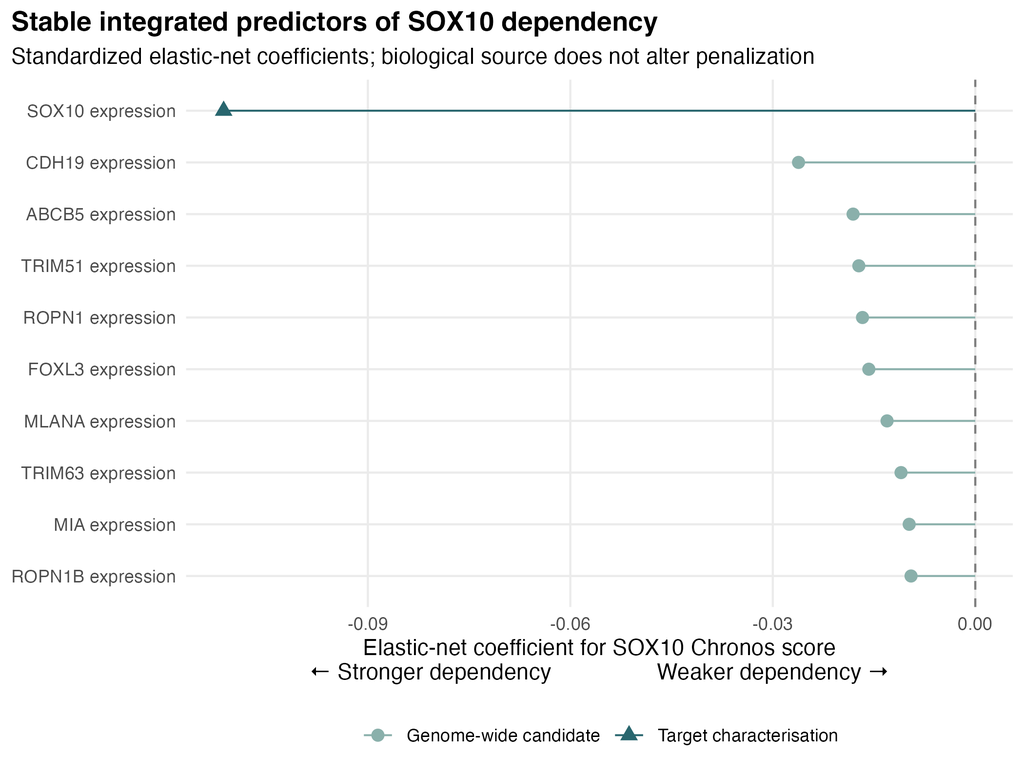

**SOX10 expression** was kept in **15 of 15** repeated model fits. In **100%** of those fits, higher SOX10 expression pointed toward **stronger SOX10 dependency**. In the full-data model, a one-SD increase changed the predicted Chronos score by **-0.111**.

**CDH19 expression** was kept in **15 of 15** repeated model fits. In **100%** of those fits, higher CDH19 expression pointed toward **stronger SOX10 dependency**. In the full-data model, a one-SD increase changed the predicted Chronos score by **-0.0262**.

**ABCB5 expression** was kept in **15 of 15** repeated model fits. In **100%** of those fits, higher ABCB5 expression pointed toward **stronger SOX10 dependency**. In the full-data model, a one-SD increase changed the predicted Chronos score by **-0.0181**.

**MLANA expression** was kept in **14 of 15** repeated model fits. In **100%** of those fits, higher MLANA expression pointed toward **stronger SOX10 dependency**. In the full-data model, a one-SD increase changed the predicted Chronos score by **-0.0131**.

**MIA expression** was kept in **14 of 15** repeated model fits. In **100%** of those fits, higher MIA expression pointed toward **stronger SOX10 dependency**. In the full-data model, a one-SD increase changed the predicted Chronos score by **-0.00979**.

**ROPN1 expression** was kept in **13 of 15** repeated model fits. In **100%** of those fits, higher ROPN1 expression pointed toward **stronger SOX10 dependency**. In the full-data model, a one-SD increase changed the predicted Chronos score by **-0.0167**.

**TRIM51 expression** was kept in **12 of 15** repeated model fits. In **100%** of those fits, higher TRIM51 expression pointed toward **stronger SOX10 dependency**. In the full-data model, a one-SD increase changed the predicted Chronos score by **-0.0173**.

**FOXL3 expression** was kept in **12 of 15** repeated model fits. In **100%** of those fits, higher FOXL3 expression pointed toward **stronger SOX10 dependency**. In the full-data model, a one-SD increase changed the predicted Chronos score by **-0.0158**.

**TRIM63 expression** was kept in **12 of 15** repeated model fits. In **100%** of those fits, higher TRIM63 expression pointed toward **stronger SOX10 dependency**. In the full-data model, a one-SD increase changed the predicted Chronos score by **-0.011**.

**ROPN1B expression** was kept in **11 of 15** repeated model fits. In **100%** of those fits, higher ROPN1B expression pointed toward **stronger SOX10 dependency**. In the full-data model, a one-SD increase changed the predicted Chronos score by **-0.00952**.

**View integrated-model coefficients**

Stable molecular predictors

|  | Feature | Source | Direction | Chronos change per 1 SD | Selected model fits | Direction agreement |
| --- | --- | --- | --- | --- | --- | --- |
| 1 | SOX10 expression | Target characterisation | Stronger SOX10 dependency | -0.111 | 15 of 15 | 100% |
| 2 | CDH19 expression | Genome-wide candidate | Stronger SOX10 dependency | -0.026 | 15 of 15 | 100% |
| 3 | ABCB5 expression | Genome-wide candidate | Stronger SOX10 dependency | -0.018 | 15 of 15 | 100% |
| 7 | TRIM51 expression | Genome-wide candidate | Stronger SOX10 dependency | -0.017 | 12 of 15 | 100% |
| 6 | ROPN1 expression | Genome-wide candidate | Stronger SOX10 dependency | -0.017 | 13 of 15 | 100% |
| 8 | FOXL3 expression | Genome-wide candidate | Stronger SOX10 dependency | -0.016 | 12 of 15 | 100% |
| 4 | MLANA expression | Genome-wide candidate | Stronger SOX10 dependency | -0.013 | 14 of 15 | 100% |
| 9 | TRIM63 expression | Genome-wide candidate | Stronger SOX10 dependency | -0.011 | 12 of 15 | 100% |
| 5 | MIA expression | Genome-wide candidate | Stronger SOX10 dependency | -0.010 | 14 of 15 | 100% |
| 10 | ROPN1B expression | Genome-wide candidate | Stronger SOX10 dependency | -0.010 | 11 of 15 | 100% |

# Performance on held-out cell lines

The model was tested on cell lines that were not used to train it. This estimates how well its predictions may generalise to new data.

**Pearson r** compares the pattern of predicted and observed values. It asks whether cell lines predicted to have high dependency scores actually have high observed scores, and whether those predicted to have low scores actually have low observed scores. The mean held-out Pearson r was **0.802** (range 0.799 to 0.808), showing how closely the model ranked observed dependency scores. The Pearson r results were **similar across repeats**.

**R-squared** measures numerical prediction accuracy by comparing the model’s total squared prediction errors with those from assigning every cell line the average observed dependency score. An R-squared of 1 represents perfect predictions, 0 means the model is no better than that average-only reference, and a negative value means it is worse. The mean held-out R-squared was **0.639** (range 0.634 to 0.648). On average, the model reduced the total squared prediction error by approximately **63.9%** relative to assigning every cell line the average observed `SOX10` dependency score. The R-squared results were **similar across repeats**.

**RMSE** summarises the typical size of the difference between predicted and observed dependency scores, with larger errors receiving more weight. The mean held-out RMSE was **0.267 Chronos units** (range 0.264 to 0.269), equivalent to **60.0%** of the observed `SOX10` dependency SD of 0.444. Lower values indicate predictions closer to the observed scores, and 0 represents perfect predictions. The RMSE results were **similar across repeats**.

Based on R-squared, the model therefore had **strong held-out predictive performance**.

This performance describes the complete model, including cancer lineage and all molecular features selected within each training fold. It cannot be attributed to any single retained gene.

For exploratory feature prioritisation, a positive and consistent held-out R-squared indicates useful signal. Accurate prediction of individual cell lines would require substantially smaller errors and independent validation.

## Observed versus predicted dependency

The three panels show the three complete cross-validation repeats. Every point is a cell line predicted while it was held out from model fitting and feature selection. The dashed diagonal marks a perfect prediction, where the predicted score equals the observed score. The vertical distance between a point and this line is the prediction error for that cell line: larger distances increase RMSE and reduce R-squared.

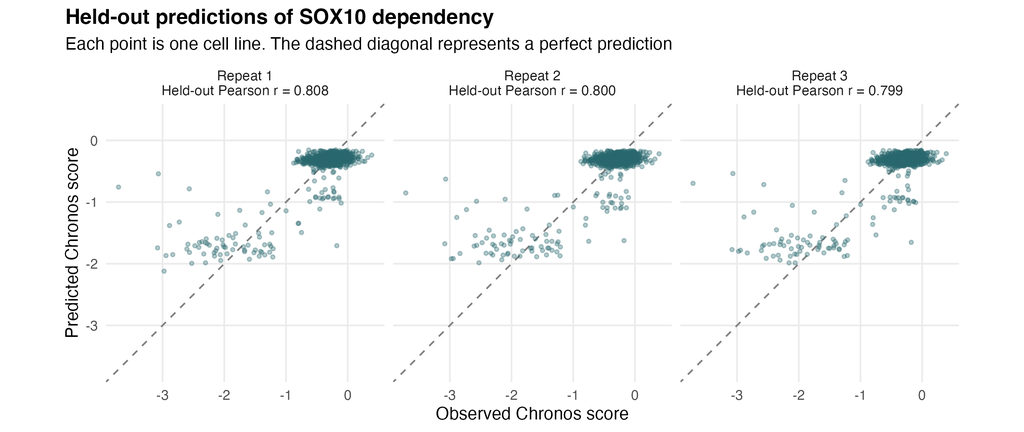

## Performance by lineage

This comparison asks whether the model predicts differences among cell lines *within* each cancer lineage. A lineage R-squared above zero means the model improves on assigning every cell line that lineage’s average dependency score; a negative value means it performs worse than that simple reference. Only lineages with at least 20 models are shown. Lineage estimates are less precise than the pan-cancer result and should be treated as diagnostic rather than as separate validated models.

The model had positive held-out R-squared in **4 of 20 lineages**, and **3 lineages reached R-squared 0.10**. The highest value was observed in **Skin** (R-squared 0.488; RMSE 0.589), while the lowest was observed in **Liver** (R-squared -0.176; RMSE 0.162).

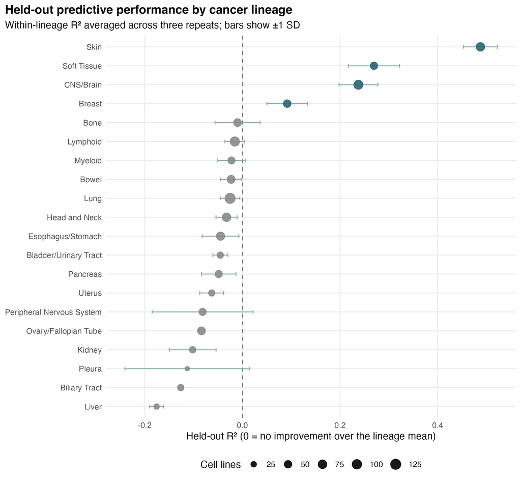

**View lineage-performance values**

Held-out performance by lineage, averaged across three repeats

| Lineage | N | MAE | RMSE | R-squared | R-squared SD |
| --- | --- | --- | --- | --- | --- |
| Skin | 75 | 0.506 | 0.589 | 0.488 | 0.035 |
| Soft Tissue | 49 | 0.175 | 0.309 | 0.269 | 0.053 |
| CNS/Brain | 91 | 0.171 | 0.361 | 0.238 | 0.040 |
| Breast | 53 | 0.188 | 0.386 | 0.092 | 0.042 |
| Bone | 58 | 0.132 | 0.167 | -0.010 | 0.046 |
| Lymphoid | 96 | 0.130 | 0.176 | -0.016 | 0.020 |
| Myeloid | 45 | 0.155 | 0.196 | -0.023 | 0.028 |
| Bowel | 63 | 0.151 | 0.194 | -0.023 | 0.022 |
| Lung | 126 | 0.128 | 0.160 | -0.025 | 0.020 |
| Head and Neck | 77 | 0.115 | 0.141 | -0.033 | 0.022 |
| Esophagus/Stomach | 69 | 0.116 | 0.148 | -0.045 | 0.038 |
| Bladder/Urinary Tract | 34 | 0.145 | 0.188 | -0.045 | 0.015 |
| Pancreas | 48 | 0.143 | 0.189 | -0.049 | 0.035 |
| Uterus | 34 | 0.152 | 0.198 | -0.063 | 0.025 |
| Peripheral Nervous System | 47 | 0.161 | 0.231 | -0.082 | 0.103 |
| Ovary/Fallopian Tube | 59 | 0.115 | 0.150 | -0.084 | 0.006 |
| Kidney | 35 | 0.126 | 0.170 | -0.102 | 0.048 |
| Pleura | 21 | 0.181 | 0.242 | -0.113 | 0.128 |
| Biliary Tract | 34 | 0.178 | 0.208 | -0.126 | 0.006 |
| Liver | 25 | 0.117 | 0.162 | -0.176 | 0.014 |

**View cross-validation details**

Nested-cross-validation performance by repeat

| Repeat | N | Outer folds | Inner folds | Alpha | Lambda rule | RMSE | Pearson r | R-squared |
| --- | --- | --- | --- | --- | --- | --- | --- | --- |
| 1 | 1208 | 5 | 5 | 0.5 | lambda.1se | 0.264 | 0.808 | 0.648 |
| 2 | 1208 | 5 | 5 | 0.5 | lambda.1se | 0.268 | 0.800 | 0.635 |
| 3 | 1208 | 5 | 5 | 0.5 | lambda.1se | 0.269 | 0.799 | 0.634 |

# Conclusion, interpretation and limitations

This report asked which molecular features are associated with dependency on **SOX10** and whether exploratory molecular predictors recur when all eligible modalities are considered jointly. It first described dependency and lineage patterns, retained the pan-cancer univariate screens as descriptive analyses, and followed eligible target/pre-specified-hypothesis associations within individual lineages. The integrated model then allowed every eligible molecular feature to compete under the same elastic-net penalty while keeping lineage as an unpenalized adjustment.

The resulting stable genes, when present, are exploratory molecular predictors rather than causal genes or independently significant effects. Their evidence is summarized by repeated outer-fold selection frequency, coefficient-direction concordance, persistence in the full-data fit and nested-CV performance.

Specifically:

Across **1208 pancancer models**, the median `SOX10` Chronos score was **-0.306**, and **16.7%** of models had a score below -0.5. Dependency varied across cancer lineages, with **Skin** and **Eye** among the contexts showing a stronger dependency than models from remaining lineages.

The stable molecular predictor set contained **SOX10 expression**, **CDH19 expression**, **ABCB5 expression**, **MLANA expression**, **MIA expression**, **ROPN1 expression**, **TRIM51 expression**, **FOXL3 expression**, **TRIM63 expression**, **ROPN1B expression**. These findings require independent biological validation.

These results provide a prioritisation map for validation in independent, lineage-balanced models. Copy number predictors should also be tested to determine whether they represent the named gene or a broader chromosomal event. A useful next experiment is to ask whether a stable or near-miss predictor reproducibly separates models with stronger and weaker SOX10 dependency under an independent genetic or pharmacological perturbation.

The inverse question: *which dependencies are selective in models carrying mutation of a chosen tumour suppressor?* requires a different feature-centric genome-wide dependency screen and remains outside this repository’s current scope. However, a good starting point is [Haider *et al.*, Nature Genetics 57, 522–529 (2025)](https://www.nature.com/articles/s41588-025-02108-2), and its associated [SYLVER app](https://software.icr.ac.uk/app/sylver/) for exploring selective dependencies in the context of specific mutations. Stay in touch with the repository for future developments.

# Reproducibility

The pipeline saves summary tables, figures and the completed report locally. Raw DepMap matrices and cell-line-level intermediate files remain excluded from version control; users must obtain the source data from DepMap (see README) and regenerate the intermediate files by running the pipeline to obtain a copy of this report with a new target gene.